# 18. Linear Regression 5 (Interaction 2)

Masahiko Asano

2025-12-04

- `R packages we use in this section`

```r
library(broom)
library(ggstance)
library(interplot)
library(margins)
library(msm)
library(patchwork)
library(stargazer)
library(tidyverse)
```

# 1. Two ways of showing marginal effects

### Is moderator variable `categorial` or `continous`?

- Depending on the type of moderator variable, you need to change the way of showing your results.

#### Exmaple:

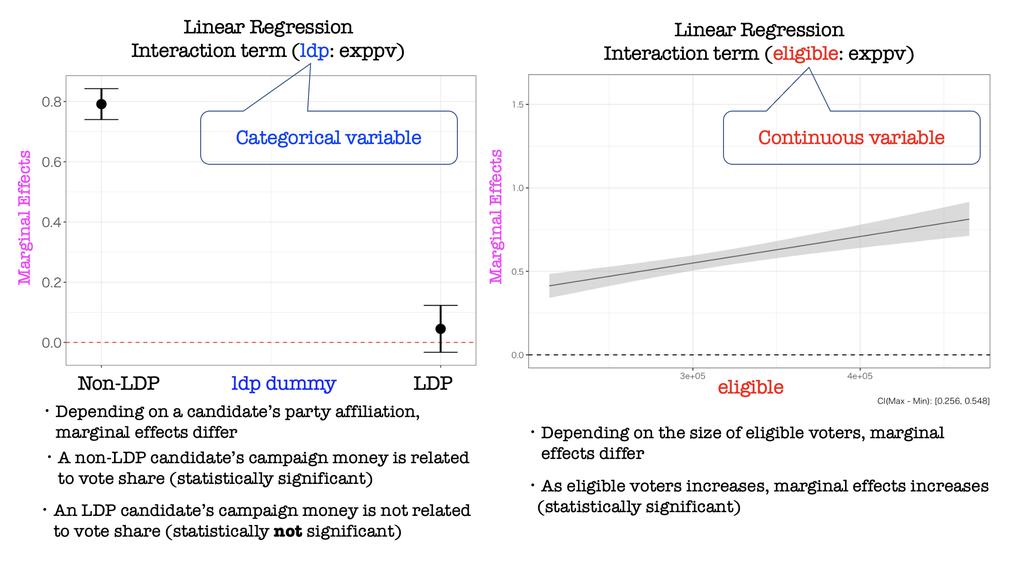

#### WHAT WE WANT TO KNOW:

**Does the impact of campaign expenditure on vote share differ depending on the number of eligible voters?**

- When we estimate a model with an interaction term, we need to check **Marginal Effects**

# 2. Date preparation

- Download hr96_17.csv
- Japanese lower house election results (1996-2017)
- Put the file (hr96_17.csv) into `data` folder in your `RProject` folder
- Load the data and name it `hr`

```r
hr <- read_csv("data/hr96-17.csv",
               na = ".")
```

- Check the variable names in `hr`

```r
names(hr)
```

```
 [1] "year"          "pref"          "ku"            "kun"
 [5] "wl"            "rank"          "nocand"        "seito"
 [9] "j_name"        "gender"        "seshu_dummy"   "jiban_seshu"
[13] "name"          "previous"      "...15"         "age"
[17] "exp"           "status"        "vote"          "voteshare"
[21] "eligible"      "turnout"       "castvotes"     "...24"
[25] "...25"         "nojiban_seshu" "mag"
```

- Check how many lower elections we had since 1996 to date

```r
unique(hr$year)
```

```
[1] 1996 2000 2003 2005 2009 2012 2014 2017 2021
```

```r
df1 <- hr %>%
  dplyr::filter(year == 2005) %>%
  dplyr::select(year, age, voteshare, exp, eligible, nocand, previous)
```

- Check df1

```r
DT::datatable(df1)
```

|  | year | age | voteshare | exp | eligible | nocand | previous |
| --- | --- | --- | --- | --- | --- | --- | --- |
| 1 | 2005 | 56 | 50 | 6136854 | 360007 | 4 | 4 |
| 2 | 2005 | 32 | 39.1 | 14409252 | 360007 | 4 | 0 |
| 3 | 2005 | 56 | 3.6 | 4702496 | 360007 | 4 | 0 |
| 4 | 2005 | 55 | 7.4 | 2177427 | 360007 | 4 | 0 |
| 5 | 2005 | 27 | 39.1 | 5289828 | 366121 | 3 | 0 |
| 6 | 2005 | 39 | 52 | 11075148 | 366121 | 3 | 3 |
| 7 | 2005 | 50 | 8.9 | 2016750 | 366121 | 3 | 0 |
| 8 | 2005 | 47 | 49 | 7005984 | 367839 | 4 | 3 |
| 9 | 2005 | 40 | 9 | 1580848 | 367839 | 4 | 0 |
| 10 | 2005 | 45 | 3.8 | 641455 | 367839 | 4 | 0 |

[output cut: 979 more lines]

| variable | detail |
| --- | --- |
| year | Election Year |
| age | Candidate’s age |
| voteshare | Voteshare (%) |
| exp | Election expenditure (yen) spent by each candidate |
| eligible | Eligible voters in each district |
| nocand | Number of candidates in each district |
| previous | Number of previouss served as a lower house member |

- We need campaign expenditure variable (`exppv`)
- `exppv` show campaign expenditure spent by each candidate per voter in their electoral district.

```r
df1 <- mutate(df1, exppv = exp / eligible)
```

- We need eligible voter variable (`eligible.t`)
- `eligible.t` show the number of eligible voters by thousand

```r
df1 <- mutate(df1, eligible.t = eligible / 1000)
```

```r
DT::datatable(df1)
```

|  | year | age | voteshare | exp | eligible | nocand | previous | exppv | eligible.t |
| --- | --- | --- | --- | --- | --- | --- | --- | --- | --- |
| 1 | 2005 | 56 | 50 | 6136854 | 360007 | 4 | 4 | 17.04648520723208 | 360.007 |
| 2 | 2005 | 32 | 39.1 | 14409252 | 360007 | 4 | 0 | 40.02492173763288 | 360.007 |
| 3 | 2005 | 56 | 3.6 | 4702496 | 360007 | 4 | 0 | 13.06223490098804 | 360.007 |
| 4 | 2005 | 55 | 7.4 | 2177427 | 360007 | 4 | 0 | 6.048290727680295 | 360.007 |
| 5 | 2005 | 27 | 39.1 | 5289828 | 366121 | 3 | 0 | 14.44830534167666 | 366.121 |
| 6 | 2005 | 39 | 52 | 11075148 | 366121 | 3 | 3 | 30.24996654111619 | 366.121 |
| 7 | 2005 | 50 | 8.9 | 2016750 | 366121 | 3 | 0 | 5.508424810376897 | 366.121 |
| 8 | 2005 | 47 | 49 | 7005984 | 367839 | 4 | 3 | 19.04633277058713 | 367.839 |
| 9 | 2005 | 40 | 9 | 1580848 | 367839 | 4 | 0 | 4.297662836186483 | 367.839 |
| 10 | 2005 | 45 | 3.8 | 641455 | 367839 | 4 | 0 | 1.743847172268302 | 367.839 |

[output cut: 979 more lines]

- Show the descriptive statistics of `df1`

```r
stargazer(as.data.frame(df1), type = "html")
```

| Statistic | N | Mean | St. Dev. | Min | Max |
| --- | --- | --- | --- | --- | --- |
| year | 989 | 2,005.000 | 0.000 | 2,005 | 2,005 |
| age | 989 | 50.292 | 10.871 | 25 | 81 |
| voteshare | 989 | 30.333 | 19.230 | 0.600 | 73.600 |
| exp | 985 | 8,142,244.000 | 5,569,641.000 | 62,710 | 24,649,710 |
| eligible | 989 | 344,654.300 | 63,898.230 | 214,235 | 465,181 |
| nocand | 989 | 3.435 | 0.740 | 2 | 6 |
| previous | 989 | 1.550 | 2.412 | 0 | 15 |
| exppv | 985 | 24.627 | 17.907 | 0.148 | 89.332 |
| eligible.t | 989 | 344.654 | 63.898 | 214.235 | 465.181 |

## 3. Draw two scatter plots

```r
F1 <- ggplot(df1, aes(exppv, voteshare)) +
  geom_point() +
  labs(x = "Campaign expenditure per voter (yen)", y = "vote share(%)",
         title = "Campagin expenditure and vote share") +
  stat_smooth(method = lm, se = FALSE)
```

```r
F2 <- ggplot(df1, aes(eligible.t, voteshare)) +
  geom_point() +
  labs(x = "Eligible Voters (thousands)", y = "vote share(%)",
         title = "Eligible Voters and vote share") +
  stat_smooth(method = lm, se = FALSE)
```

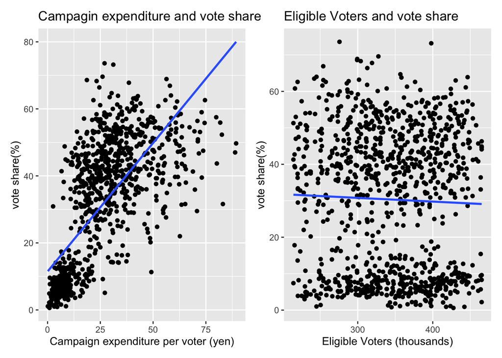

```r
F1 + F2 + plot_layout(ncol = 2)
```

- We can see a positive relation between `exppv` and `voteshare`
- We can see a very weak negative relation between `eligible.t` and `voteshare`

# 4. Model_1

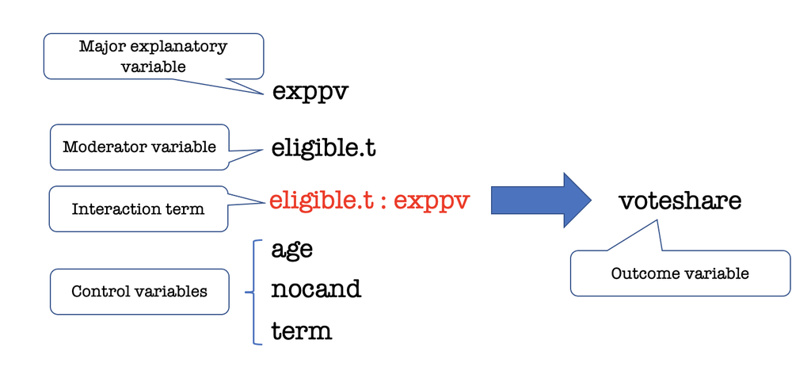

- `age`, `nocand`, and `previous` are control variables

Note ・**A control variable** is anything that is held constant or limited in a research study.  
・It’s a variable that is not of interest to our research aims, but is controlled because it could influence the outcomes.  
・In actual research, we need to add more control variables because it is reasonable for us to assume other variables (such as age of candidates, campaign expenditure, candidate’s gender, etc.) which could influence the votes share.  
・Here I add three control variables; `age`, `nocand`, and`previous.`

## 4.1 Interaction term & marginal effects

- To see interaction effects, we make an interaction term by multiplying the major independent variable (in this case, `exppv`) and a numerical moderator variable (in this case, `eligible.t`): **`eligible.t:exppv`**
- We make an interaction term by multiplying the following two independent variables:
1. major explanatory variable (`exppv`)
2. moderator variable (`eligible.t`)

Note ・A moderator variable can be two types: categorical and continuous variables.  
・In this section, I will deal with a moderator variable (numeric).  
・In `20. Multiple Regression 3 (Interaction Effects 1)`, I will deal with a moderator variable (categorical).

- We include this interaction term in `Model_1`
- This way, we can see how a third variable (`eligible.t`) influences the relationship between an explanatory and outcome variable.

#### Assumption of model_1:

- The slope (`exppv` → `voteshare`) differs bdepending on the number of eligible.t voters.
- This slope is equivalent to **`Marginal Effect`**
- We estimate the following model:

$$voteshare = α_1 + α_2 exppv + α_3
eligible.t + α_{4} eligible.t:exppv +\\
α_{5} age + α_{6} nocand + α_{7} previous + ε$$

- We can rewrite the equation as follows:

$$voteshare = α_1 + (α_2 + α_{4}
eligible.t) exppv + α_3 eligible.t\\
+ α_{5}age + α_{6} nocand + α_{7} previous +ε$$

| $\alpha_2$ | vote share (%) of a candidate when `eligible.t = 0` |
| --- | --- |
| $(\alpha_2 + \alpha_4 \textrm{eligible.t})$ | slope (`exppv` → `voteshare`)= Marginal Effect |

#### WHAT WE WANT TO KNOW:

**Does the impact of campaign expenditure on vote share differ depending on the number of eligible.t voters?**

- When we estimate a model with an interaction term, we need to check **Marginal Effects**

Marginal Effects ・Marginal effects are often calculated when analyzing regression analysis results.  
・Marginal effects are equivalent to `slopes` in regression analysis.  
・Marginal effects tells us how a dependent variable (outcome) changes when a specific independent variable (explanatory variable) changes.  
・Other covariates (= control variables) are assumed to be held constant.  
→ In this case, we hold `age`, `nocand`, and `previous` constant.

## 4.2 Results (Model_1)

```r
model_1 <- lm(voteshare ~ exppv*eligible.t + age + nocand + previous,
              data = df1)
```

#### Visually show the results: `jtools::plot_summs()`

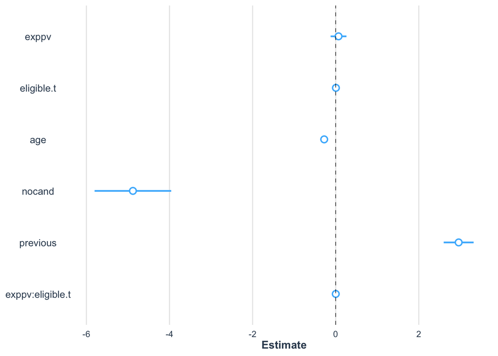

```r
jtools::plot_summs(model_1)
```

#### Show the results: `tidy()`

```r
tidy(model_1)
```

```
# A tibble: 7 × 5
  term             estimate std.error statistic  p.value
  <chr>               <dbl>     <dbl>     <dbl>    <dbl>
1 (Intercept)      38.7      3.95         9.80  1.12e-21
2 exppv             0.0682   0.0972       0.702 4.83e- 1
3 eligible.t        0.00536  0.00914      0.586 5.58e- 1
4 age              -0.277    0.0355      -7.81  1.50e-14
5 nocand           -4.88     0.470      -10.4   4.86e-24
6 previous          2.96     0.184       16.1   5.28e-52
7 exppv:eligible.t  0.00175  0.000302     5.78  9.93e- 9
```

#### Show the results: `stargazer()`

```r
stargazer(model_1,
          digits = 3,
          style = "ajps",
          title = "Results of model_1 (2005HR election)",
          type ="html")
```

|  | **voteshare** |
| --- | --- |
| exppv | 0.068 |
|  | (0.097) |
| eligible.t | 0.005 |
|  | (0.009) |
| age | -0.277*** |
|  | (0.035) |
| nocand | -4.881*** |
|  | (0.470) |
| previous | 2.960*** |
|  | (0.184) |
| exppv:eligible.t | 0.002*** |
|  | (0.0003) |
| Constant | 38.680*** |
|  | (3.949) |
| N | 985 |
| R-squared | 0.691 |
| Adj. R-squared | 0.689 |
| Residual Std. Error | 10.706 (df = 978) |
| F Statistic | 364.721*** (df = 6; 978) |
| p < .01; p < .05; p < .1 |  |

## 4.3 Interpretation (model_1)

- In interpreting `model_1`, let’s make another model which does not include the interaction term (`model_2`) and compare them to have a better understanding of the results.

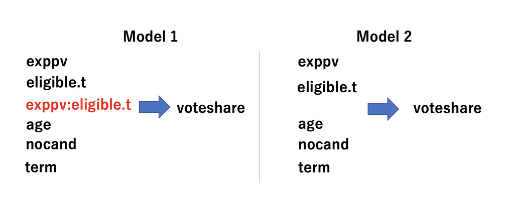

- Let’s make model_2

```r
model_2 <- lm(voteshare ~ exppv + eligible.t + age + nocand + previous,
              data = df1)
```

#### Show the results: `stargazer()`

```r
stargazer(model_1, model_2,
          digits = 3,
          style = "ajps",
          title = "Results of model_1 and model_2(2005HR election)",
          type ="html")
```

|  | **voteshare** |  |
| --- | --- | --- |
|  | **Model 1** | **Model 2** |
| exppv | 0.068 | 0.614*** |
|  | (0.097) | (0.024) |
| eligible.t | 0.005 | 0.047*** |
|  | (0.009) | (0.006) |
| age | -0.277*** | -0.279*** |
|  | (0.035) | (0.036) |
| nocand | -4.881*** | -4.909*** |
|  | (0.470) | (0.478) |
| previous | 2.960*** | 3.130*** |
|  | (0.184) | (0.184) |
| exppv:eligible.t | 0.002*** |  |
|  | (0.0003) |  |
| Constant | 38.680*** | 25.169*** |
|  | (3.949) | (3.235) |
| N | 985 | 985 |
| R-squared | 0.691 | 0.681 |
| Adj. R-squared | 0.689 | 0.679 |
| Residual Std. Error | 10.706 (df = 978) | 10.882 (df = 979) |
| F Statistic | 364.721*** (df = 6; 978) | 417.161*** (df = 5; 979) |
| p < .01; p < .05; p < .1 |  |  |

```r
tidy(model_1)
```

```
# A tibble: 7 × 5
  term             estimate std.error statistic  p.value
  <chr>               <dbl>     <dbl>     <dbl>    <dbl>
1 (Intercept)      38.7      3.95         9.80  1.12e-21
2 exppv             0.0682   0.0972       0.702 4.83e- 1
3 eligible.t        0.00536  0.00914      0.586 5.58e- 1
4 age              -0.277    0.0355      -7.81  1.50e-14
5 nocand           -4.88     0.470      -10.4   4.86e-24
6 previous          2.96     0.184       16.1   5.28e-52
7 exppv:eligible.t  0.00175  0.000302     5.78  9.93e- 9
```

Important point **The results of Model_1 is the results when eligible.t = 0**  
→ **Since eligible.t = 0 is unrealistic, we need to check marginal efffects when the number of eligible.t voters varies.**

- The coefficient of `exppv` (0.068) in model_1  
  → when `exppv` increased one yen, `voteshare` increased by 0.068 percentage points when eligible.t = 0.
- To confirm this, let’s check the Sample Regression Function equations for model_1.

$$\widehat{voteshare}\ = 38.7 + 0.068exppv
+ 0.002eligible:exppv + 0.005eligible.t \\ - 0.28age - 4.9 nocand +
2.96previous$$
$$= 38.7 + (0.068 + 0.002eligible)exppv +
0.005eligible - 0.28age \\- 4.9 nocand + 2.96previous$$

- The impact of `exppv` on `voteshare` $(α_2 + α_4eligible)$ is:

$${0.068 +
0.002eligible}$$

- **0.068 + 0.002eligible** means the marginal effect（`exppv` → `voteshare`）when the number of eligible.t voter increases by one unit (which means one thousand voters), then vote share increases by 0.068 percentage points (0.068 + 0.002*1 = 0.07)
- We see that marginal effects change depending on the value of `eligible.t`

# 5. Visualize Marginal Effects (Model_1)

- Show the `intercept` and `coefficients` of `model_1`

```r
model_1$coef
```

```
     (Intercept)            exppv       eligible.t              age
    38.680300268      0.068168095      0.005359147     -0.276786422
          nocand         previous exppv:eligible.t
    -4.880536533      2.959739246      0.001746856
```

- Check the descriptive statistics of moderator (in this case, `eligible.t`)

```r
summary(df1$eligible.t)
```

```
   Min. 1st Qu.  Median    Mean 3rd Qu.    Max.
  214.2   297.4   347.9   344.7   397.2   465.2
```

- Make 6 values on `eligible.t` between its min (214.2) and max (465.2) with the interval of 50.
- Calculate the marginal effects (= slopes) for the 6 values
- We need the 2nd coefficient (`exppv`) and the 7th coefficients (`exppv:eligible`) to calculate these marginal effects.

```r
at.eligible.t <- seq(214.2, 465.2, 50)
slopes <- model_1$coef[2] + model_1$coef[7]*at.eligible.t
slopes
```

```
[1] 0.4423446 0.5296874 0.6170302 0.7043730 0.7917158 0.8790586
```

- Using `delta method`, we calculate `standard error` with 95% confidence intervals for each marginal effects.

```r
library(msm)
```

```r
estmean <- coef(model_1)
var <- vcov(model_1)

SEs <- rep(NA, length(at.eligible.t))

for (i in 1:length(at.eligible.t)){
    j <- at.eligible.t[i]
    SEs[i] <- deltamethod (~ (x2) + (x7)*j, estmean, var)
}

upper <- slopes + 1.96*SEs  # 5% significant level
lower <- slopes - 1.96*SEs  # 5% significant level

cbind(at.eligible.t, slopes, upper, lower)
```

```
     at.eligible.t    slopes     upper     lower
[1,]         214.2 0.4423446 0.5161208 0.3685684
[2,]         264.2 0.5296874 0.5833488 0.4760261
[3,]         314.2 0.6170302 0.6625217 0.5715388
[4,]         364.2 0.7043730 0.7592613 0.6494847
[5,]         414.2 0.7917158 0.8672757 0.7161559
[6,]         464.2 0.8790586 0.9798515 0.7782658
```

[figure not shown]

##### ★ `upper` and `lower` show the upper & the lower bound on 95% confidence intervals.

→ This is important information when you check their statistical significance.

- To visualize this result, we change the data into data frame and name it `msm_1`

```r
msm_1 <- cbind(at.eligible.t, slopes, upper, lower) %>%
  as.data.frame()

msm_1
```

```
  at.eligible.t    slopes     upper     lower
1         214.2 0.4423446 0.5161208 0.3685684
2         264.2 0.5296874 0.5833488 0.4760261
3         314.2 0.6170302 0.6625217 0.5715388
4         364.2 0.7043730 0.7592613 0.6494847
5         414.2 0.7917158 0.8672757 0.7161559
6         464.2 0.8790586 0.9798515 0.7782658
```

- Draw a graph showing the marginal effects of `exppv` on `voteshare` for the size of eligible voters

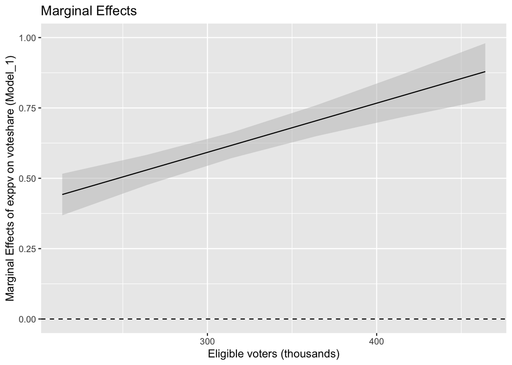

```r
msm_1 <- msm_1 %>%
  ggplot(aes(x = at.eligible.t,
             y = slopes,
             ymin = lower,
             ymax = upper)) +
  geom_hline(yintercept = 0, linetype = 2) +
  geom_ribbon(alpha = 0.5, fill = "gray") +
  geom_line() +
  labs(x = "Eligible voters (thousands)",
     y = "Marginal Effects of exppv on voteshare (Model_1)") +
  ggtitle('Marginal Effects') +
  ylim(0, 1)

msm_1
```

Conclusion ・As the number of eligible voter increases, the impact of campaign expenditure on vote share increases.  
・This is statistically significant with the 5% significant level.

# 6. Statistical Significance (Marginal Effects)

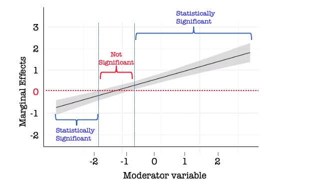

# 7. How to show Marginal Effects

- Using `msm package` is one way of visualize the results on marginal effects.
- Let me introduce the other two packages to visualize the results.

## 7.1 `interplot`

```r
library("interplot")
```

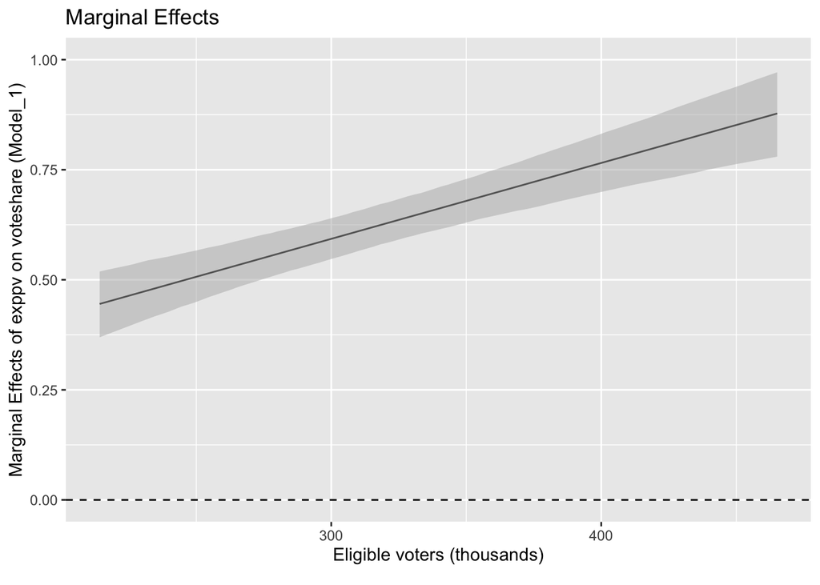

```r
interplot_1 <- interplot(m = model_1,
          var1 = "exppv",           # Major independent variable
          var2 = "eligible.t") +    # Moderator variable
labs(x = "Eligible voters (thousands)",
     y = "Marginal Effects of exppv on voteshare (Model_1)") +
  ggtitle('Marginal Effects') +
  geom_hline(yintercept = 0, linetype = 2) +
  ylim(0, 1)

interplot_1
```

## 7.2 `margins`

```r
library("margins")
```

```r
margins_1 <- cplot(model_1,
                   x = "eligible.t",  # Moderator variable
                   dx = "exppv", 　   # Major independent variable
                   what = "effect",   # Marginal Effects
                   n = 6,             # Number assigned
                   draw = FALSE)
margins_1
```

```
    xvals  yvals  upper  lower factor
 214.2350 0.4424 0.5162 0.3686  exppv
 264.4242 0.5301 0.5837 0.4765  exppv
 314.6134 0.6178 0.6632 0.5723  exppv
 364.8026 0.7054 0.7605 0.6503  exppv
 414.9918 0.7931 0.8690 0.7172  exppv
 465.1810 0.8808 0.9821 0.7795  exppv
```

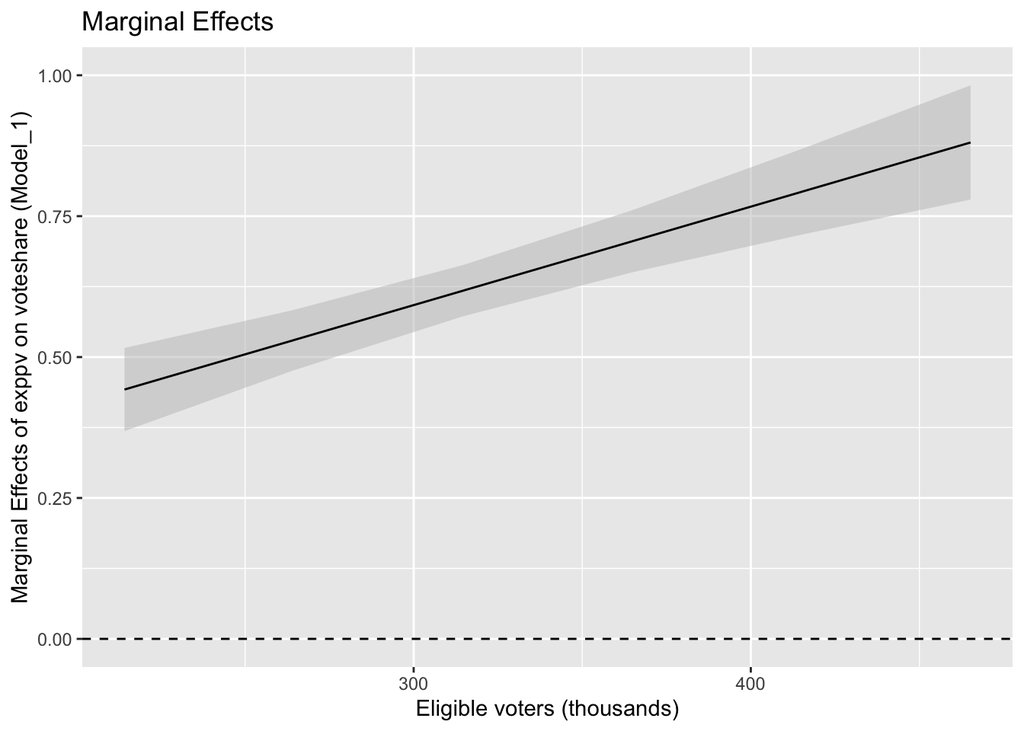

```r
margins_1 <- margins_1  %>%
  ggplot(aes(x = xvals, y = yvals, ymin = lower, ymax = upper)) +
  geom_hline(yintercept = 0, linetype = 2) +
  geom_ribbon(alpha = 0.5, fill = "gray") +
  geom_line() +
  labs(x = "Eligible voters (thousands)",
     y = "Marginal Effects of exppv on voteshare (Model_1)") +
  ggtitle('Marginal Effects') +
  ylim(0, 1)

margins_1
```

# 8. Exercise

- We want know whether the impact of campaign expenditure (`exppv`) on vote share (`voteshare`) differ as the number of winning (`previous`) for candidates in the **2012 lower house election** in Japan.
- The 2012 lower house election is known for Prime Minister Abe’s coming back to power election.
- Data you use: hr96-24.csv
- Japanese lower house election results (1996-2017)
- Extract the 2012 election data from `hr96-24.csv` and select the following 5 variables from this dataset and analyze them.

[output not shown]

- The variable `exppv` is not included in the dataset, so create it yourself using the two variables `exp` and `eligible` in `hr96-24.csv`.

**Q1**: Display the descriptive statistics for the above variables.

**Q2**: Display a scatter plot of election expenses and vote share, and briefly comment on it.

**Q3**: Display a scatter plot of the number of times elected and vote share, and briefly comment on it.

**Q4**: State your hypothesis regarding whether the impact of election expenses on vote share in the House of Representatives election is related to the number of times elected. Also, briefly state the reasons for your hypothesis.

**Q5**: Display the results of the following two multiple regression analyses using the stargazer package.

```r
model_5 <- lm(voteshare ~ exppv*previous + age + nocand,
              data = df3)

model_6 <- lm(voteshare ~ exppv + previous + age + nocand,
              data = df3)
```

**Q6**: Using the `interplot` package, illustrate the impact of election expenses on vote share. Display the results in an easily understandable graph and describe the analysis results.

**References**

[宋財泫 (Jaehyun Song)・矢内勇生 (Yuki Yanai)「私たちのR: ベストプラクティスの探究」](https://www.jaysong.net/RBook/)

[土井翔平（北海道大学公共政策大学院）「Rで計量政治学入門」](https://shohei-doi.github.io/quant_polisci/data-import.html)

[矢内勇生（高知工科大学）授業一覧](http://yukiyanai.github.io/teaching/)

浅野正彦, 矢内勇生.『Rによる計量政治学』オーム社、2018年

浅野正彦, 中村公亮.『初めてのRStudio』オーム社、2018年

Winston Chang, R Graphics Cookbook, O’Reilly Media, 2012.

Kieran Healy, DATA VISUALIZATION, Princeton, 2019

Kosuke Imai, Quantitative Social Science: An Introduction, Princeton University Press, 2017